# Attrition Model | Case ZUP

Com o imenso volume de dados sendo criado atualmente, é vital que as empresas saibam coletar e utilizar dados que possam dar a elas vantagens competitivas no mercado.

O objetivo deste case é analisar e buscar soluções para diminuir o Turnover, e aumentar a retenção de bons profissionais nas empresas.

Utilizando dados disponibilizados, construiremos um modelo de Machine Learning capaz de nos ajudar a prever possíveis atritos, que podem ajudar a empresa a tomar decisões afim de minimizar esses efeitos, aumentar a qualidade de vida no ambiente de trabalho, e reter os bons profissionais da empresa.

# Analises estatística basica das variaveis do tipo numerica

|  | Age | DailyRate | DistanceFromHome | Education | EmployeeNumber | EnvironmentSatisfaction | HourlyRate | JobInvolvement | JobLevel | JobSatisfaction | MonthlyIncome | MonthlyRate | NumCompaniesWorked | PercentSalaryHike | PerformanceRating | RelationshipSatisfaction | StockOptionLevel | TotalWorkingYears | TrainingTimesLastYear | WorkLifeBalance | YearsAtCompany | YearsInCurrentRole | YearsSinceLastPromotion | YearsWithCurrManager |
| --- | --- | --- | --- | --- | --- | --- | --- | --- | --- | --- | --- | --- | --- | --- | --- | --- | --- | --- | --- | --- | --- | --- | --- | --- |
| Mean | 36.9238095 | 802.4857143 | 9.1925170 | 2.9129252 | 1024.8653061 | 2.7217687 | 65.8911565 | 2.7299320 | 2.0639456 | 2.7285714 | 6.502931e+03 | 14313.1034014 | 2.6931973 | 15.2095238 | 3.1537415 | 2.7122449 | 0.7938776 | 11.2795918 | 2.7993197 | 2.7612245 | 7.0081633 | 4.2292517 | 2.1877551 | 4.1231293 |
| Std.Dev | 9.1353735 | 403.5090999 | 8.1068644 | 1.0241649 | 602.0243348 | 1.0930822 | 20.3294276 | 0.7115611 | 1.1069399 | 1.1028461 | 4.707957e+03 | 7117.7860441 | 2.4980090 | 3.6599377 | 0.3608235 | 1.0812089 | 0.8520767 | 7.7807817 | 1.2892706 | 0.7064758 | 6.1265252 | 3.6231370 | 3.2224303 | 3.5681361 |
| Min | 18.0000000 | 102.0000000 | 1.0000000 | 1.0000000 | 1.0000000 | 1.0000000 | 30.0000000 | 1.0000000 | 1.0000000 | 1.0000000 | 1.009000e+03 | 2094.0000000 | 0.0000000 | 11.0000000 | 3.0000000 | 1.0000000 | 0.0000000 | 0.0000000 | 0.0000000 | 1.0000000 | 0.0000000 | 0.0000000 | 0.0000000 | 0.0000000 |
| Q1 | 30.0000000 | 465.0000000 | 2.0000000 | 2.0000000 | 491.0000000 | 2.0000000 | 48.0000000 | 2.0000000 | 1.0000000 | 2.0000000 | 2.911000e+03 | 8045.0000000 | 1.0000000 | 12.0000000 | 3.0000000 | 2.0000000 | 0.0000000 | 6.0000000 | 2.0000000 | 2.0000000 | 3.0000000 | 2.0000000 | 0.0000000 | 2.0000000 |
| Median | 36.0000000 | 802.0000000 | 7.0000000 | 3.0000000 | 1020.5000000 | 3.0000000 | 66.0000000 | 3.0000000 | 2.0000000 | 3.0000000 | 4.919000e+03 | 14235.5000000 | 2.0000000 | 14.0000000 | 3.0000000 | 3.0000000 | 1.0000000 | 10.0000000 | 3.0000000 | 3.0000000 | 5.0000000 | 3.0000000 | 1.0000000 | 3.0000000 |
| Q3 | 43.0000000 | 1157.0000000 | 14.0000000 | 4.0000000 | 1556.0000000 | 4.0000000 | 84.0000000 | 3.0000000 | 3.0000000 | 4.0000000 | 8.380000e+03 | 20462.0000000 | 4.0000000 | 18.0000000 | 3.0000000 | 4.0000000 | 1.0000000 | 15.0000000 | 3.0000000 | 3.0000000 | 9.0000000 | 7.0000000 | 3.0000000 | 7.0000000 |
| Max | 60.0000000 | 1499.0000000 | 29.0000000 | 5.0000000 | 2068.0000000 | 4.0000000 | 100.0000000 | 4.0000000 | 5.0000000 | 4.0000000 | 1.999900e+04 | 26999.0000000 | 9.0000000 | 25.0000000 | 4.0000000 | 4.0000000 | 3.0000000 | 40.0000000 | 6.0000000 | 4.0000000 | 40.0000000 | 18.0000000 | 15.0000000 | 17.0000000 |
| MAD | 8.8956000 | 510.0144000 | 7.4130000 | 1.4826000 | 790.9671000 | 1.4826000 | 26.6868000 | 0.0000000 | 1.4826000 | 1.4826000 | 3.260237e+03 | 9201.7569000 | 1.4826000 | 2.9652000 | 0.0000000 | 1.4826000 | 1.4826000 | 5.9304000 | 1.4826000 | 0.0000000 | 4.4478000 | 4.4478000 | 1.4826000 | 4.4478000 |
| IQR | 13.0000000 | 692.0000000 | 12.0000000 | 2.0000000 | 1064.5000000 | 2.0000000 | 35.7500000 | 1.0000000 | 2.0000000 | 2.0000000 | 5.468000e+03 | 12414.5000000 | 3.0000000 | 6.0000000 | 0.0000000 | 2.0000000 | 1.0000000 | 9.0000000 | 1.0000000 | 1.0000000 | 6.0000000 | 5.0000000 | 3.0000000 | 5.0000000 |
| CV | 0.2474115 | 0.5028240 | 0.8818982 | 0.3515933 | 0.5874180 | 0.4016073 | 0.3085304 | 0.2606516 | 0.5363222 | 0.4041844 | 7.239746e-01 | 0.4972916 | 0.9275254 | 0.2406346 | 0.1144113 | 0.3986398 | 1.0733099 | 0.6898106 | 0.4605657 | 0.2558560 | 0.8741984 | 0.8566851 | 1.4729392 | 0.8653952 |
| Skewness | 0.4124432 | -0.0035114 | 0.9561635 | -0.2890902 | 0.0165402 | -0.3209983 | -0.0322450 | -0.4974026 | 1.0233096 | -0.3289995 | 1.367022e+00 | 0.0185399 | 1.0243772 | 0.8194530 | 1.9179623 | -0.3022098 | 0.9670037 | 1.1148929 | 0.5519959 | -0.5513533 | 1.7609300 | 0.9154918 | 1.9802422 | 0.8317508 |
| SE.Skewness | 0.0638226 | 0.0638226 | 0.0638226 | 0.0638226 | 0.0638226 | 0.0638226 | 0.0638226 | 0.0638226 | 0.0638226 | 0.0638226 | 6.382260e-02 | 0.0638226 | 0.0638226 | 0.0638226 | 0.0638226 | 0.0638226 | 0.0638226 | 0.0638226 | 0.0638226 | 0.0638226 | 0.0638226 | 0.0638226 | 0.0638226 | 0.0638226 |
| Kurtosis | -0.4103776 | -1.2062539 | -0.2319182 | -0.5646107 | -1.2255180 | -1.2049578 | -1.1988648 | 0.2615570 | 0.3891011 | -1.2245363 | 9.923007e-01 | -1.2173343 | 0.0020117 | -0.3073229 | 1.6797233 | -1.1873354 | 0.3547475 | 0.9057509 | 0.4844864 | 0.4093130 | 3.9086474 | 0.4669978 | 3.5873464 | 0.1620914 |
| N.Valid | 1470.0000000 | 1470.0000000 | 1470.0000000 | 1470.0000000 | 1470.0000000 | 1470.0000000 | 1470.0000000 | 1470.0000000 | 1470.0000000 | 1470.0000000 | 1.470000e+03 | 1470.0000000 | 1470.0000000 | 1470.0000000 | 1470.0000000 | 1470.0000000 | 1470.0000000 | 1470.0000000 | 1470.0000000 | 1470.0000000 | 1470.0000000 | 1470.0000000 | 1470.0000000 | 1470.0000000 |
| Pct.Valid | 100.0000000 | 100.0000000 | 100.0000000 | 100.0000000 | 100.0000000 | 100.0000000 | 100.0000000 | 100.0000000 | 100.0000000 | 100.0000000 | 1.000000e+02 | 100.0000000 | 100.0000000 | 100.0000000 | 100.0000000 | 100.0000000 | 100.0000000 | 100.0000000 | 100.0000000 | 100.0000000 | 100.0000000 | 100.0000000 | 100.0000000 | 100.0000000 |

Algumas informações básicas podem ser retiradas desta distribuição estatística, como por exemplo:

- A média de idade na empresa é de quase 37 anos de idade.
- A maioria dos funcionários possui Ensino Superior.
- Como se trata de um conjunto de dados oriundo dos Estados Unidos, consideramos os valores monetários como Dólar. Neste caso, o salário médio mensal da empresa é de US$6502.93.

# Analises estatística basica das variaveis do tipo texto

```
## Data Frame Summary
## df_attrition.char
## Dimensions: 1470 x 12
## Duplicates: 778
##
## +--------------------+--------------------------------+--------------------+----------+---------+
## | Variable           | Stats / Values                 | Freqs (% of Valid) | Valid    | Missing |
## +====================+================================+====================+==========+=========+
## | Attrition          | 1. No                          | 1233 (83.9%)       | 1470     | 0       |
## | [character]        | 2. Yes                         |  237 (16.1%)       | (100.0%) | (0.0%)  |
## +--------------------+--------------------------------+--------------------+----------+---------+
## | BusinessTravel     | 1. Non-Travel                  |  150 (10.2%)       | 1470     | 0       |
## | [character]        | 2. Travel_Frequently           |  277 (18.8%)       | (100.0%) | (0.0%)  |
## |                    | 3. Travel_Rarely               | 1043 (71.0%)       |          |         |
## +--------------------+--------------------------------+--------------------+----------+---------+
## | Department         | 1. Human Resources             |  63 ( 4.3%)        | 1470     | 0       |
## | [character]        | 2. Research & Development      | 961 (65.4%)        | (100.0%) | (0.0%)  |
## |                    | 3. Sales                       | 446 (30.3%)        |          |         |
## +--------------------+--------------------------------+--------------------+----------+---------+
## | EducationField     | 1. Human Resources             |  27 ( 1.8%)        | 1470     | 0       |
## | [character]        | 2. Life Sciences               | 606 (41.2%)        | (100.0%) | (0.0%)  |
## |                    | 3. Marketing                   | 159 (10.8%)        |          |         |
## |                    | 4. Medical                     | 464 (31.6%)        |          |         |
## |                    | 5. Other                       |  82 ( 5.6%)        |          |         |
## |                    | 6. Technical Degree            | 132 ( 9.0%)        |          |         |
## +--------------------+--------------------------------+--------------------+----------+---------+
## | Gender             | 1. Female                      | 588 (40.0%)        | 1470     | 0       |
## | [character]        | 2. Male                        | 882 (60.0%)        | (100.0%) | (0.0%)  |
## +--------------------+--------------------------------+--------------------+----------+---------+
## | JobRole            | 1. Healthcare Representative   | 131 ( 8.9%)        | 1470     | 0       |
## | [character]        | 2. Human Resources             |  52 ( 3.5%)        | (100.0%) | (0.0%)  |
## |                    | 3. Laboratory Technician       | 259 (17.6%)        |          |         |
## |                    | 4. Manager                     | 102 ( 6.9%)        |          |         |
## |                    | 5. Manufacturing Director      | 145 ( 9.9%)        |          |         |
## |                    | 6. Research Director           |  80 ( 5.4%)        |          |         |
## |                    | 7. Research Scientist          | 292 (19.9%)        |          |         |
## |                    | 8. Sales Executive             | 326 (22.2%)        |          |         |
## |                    | 9. Sales Representative        |  83 ( 5.6%)        |          |         |
## +--------------------+--------------------------------+--------------------+----------+---------+
## | MaritalStatus      | 1. Divorced                    | 327 (22.2%)        | 1470     | 0       |
## | [character]        | 2. Married                     | 673 (45.8%)        | (100.0%) | (0.0%)  |
## |                    | 3. Single                      | 470 (32.0%)        |          |         |
## +--------------------+--------------------------------+--------------------+----------+---------+
## | Over18             | 1. Y                           | 1470 (100.0%)      | 1470     | 0       |
## | [character]        |                                |                    | (100.0%) | (0.0%)  |
## +--------------------+--------------------------------+--------------------+----------+---------+
## | OverTime           | 1. No                          | 1054 (71.7%)       | 1470     | 0       |
## | [character]        | 2. Yes                         |  416 (28.3%)       | (100.0%) | (0.0%)  |
## +--------------------+--------------------------------+--------------------+----------+---------+
## | EmployeeCount      | 1 distinct value               | 1 : 1470 (100.0%)  | 1470     | 0       |
## | [numeric]          |                                |                    | (100.0%) | (0.0%)  |
## +--------------------+--------------------------------+--------------------+----------+---------+
## | StandardHours      | 1 distinct value               | 80 : 1470 (100.0%) | 1470     | 0       |
## | [numeric]          |                                |                    | (100.0%) | (0.0%)  |
## +--------------------+--------------------------------+--------------------+----------+---------+
## | Attrition_numeric  | Min  : 0                       | 0 : 1233 (83.9%)   | 1470     | 0       |
## | [numeric]          | Mean : 0.2                     | 1 :  237 (16.1%)   | (100.0%) | (0.0%)  |
## |                    | Max  : 1                       |                    |          |         |
## +--------------------+--------------------------------+--------------------+----------+---------+
```

A variável `Attrition` (“Atrito”), indica se o funcionário possui atrito, problema, no ambiente de trabalho. Usaremos ela como variável alvo do nosso modelo de Machine Learning. No nosso dataset, ela seria a categoria mais marcante de motivo para que o profissional saia da empresa, e por isso focamos nela.

Com acesso a mais dados, poderíamos usar outros indicadores, ou criar novas features que representem melhor a chance de um funcionário deixar a empresa.

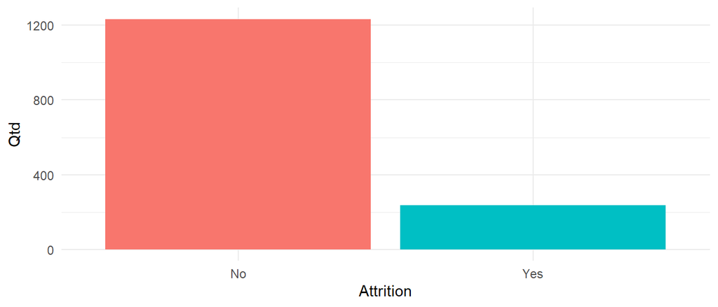

Conclusões

Isso significa que 237 (16%) dos 1470 funcionários listados nesse conjunto de dados têm atritos.

Isso pode ser aceitável, dependendo dos indicadores da empresa.

# Gráfico de Densidade

Gráficos de Densidade são ferramentas visuais poderosas, que podem nos ajudar a ter insights valiosos.

Nosso principal objetivo aqui é analisar a distribuição das variáveis para as duas possibilidades do nosso problema de classificação.

Ao analisarmos as diferenças de distribuição das variáveis para cada classe, podemos identificar variáveis mais relevantes para o nosso problema.

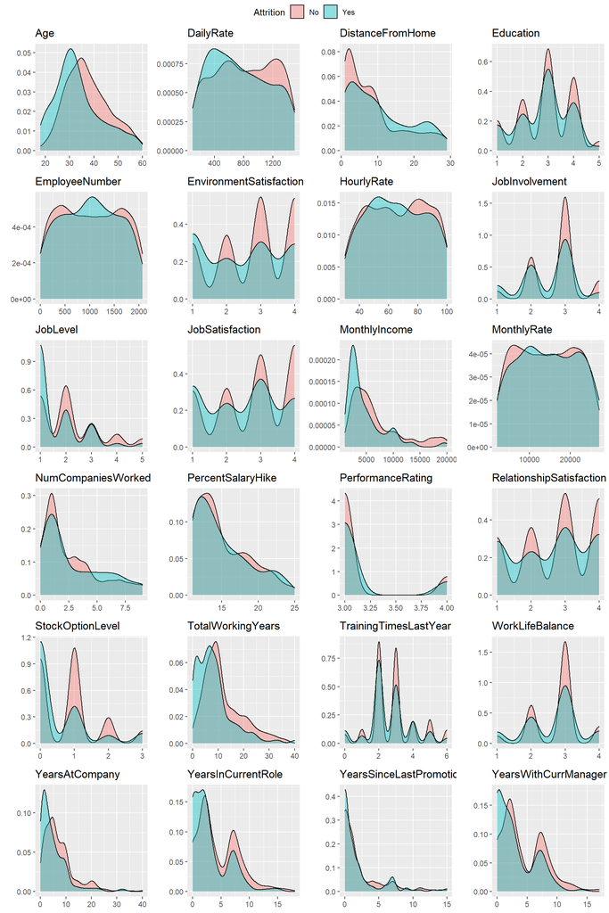

## Insights sobre os gráficos de densidade

Os Gráficos de Densidade são ferramentas interessantes para analisarmos as distribuições de acordo com as classes.

> A representação azul é para funcionários que apresentam atritos e a representação rosa para funcionários que não apresentam atrito.

O que buscamos aqui são diferenças nas distribuições para podermos encontrar pontos chave para previsão de atrito entre os funcionários.

No geral, as distribuições são bastante parecidas, não havendo grande discrepância. Por isso, destacarei aqui somente as discrepâncias entre as categorias.

Entre os principais insights obtidos, podemos destacar:

- Na variável `Age` (Idade), percebemos que quanto mais jovem, mais propensão a atrito há.
- Em relação à distância de casa (`DistanceFromHome`), percebemos que quanto maior a distância, mais propenso o funcionário está a atrito.
- Na variável `JobInvolvement`(Envolvimento no Trabalho), podemos perceber que indivíduos menos envolvidos tendem a ter mais atrito.
- `JobLevel` (Nível no Emprego) mostra que funcionários em níveis mais baixos tendem a ter mais atrito. O mesmo acontece para as variáveis `JobSatisfaction` e `MonthlyIncome`, (Satisfação no Trabalho e Renda Mensal, respectivamente).
- `StockOptionLevel` (ESOs) e `TotalWorkingYears` (Total de Anos Trabalhando), também demonstram diminuição nos atritos conforme os números aumentam.
- `YearsAtCompany` (Anos na Empresa), `YearsInCurrentRole` (Anos na Posição Atual), `YearsSinceLastPromotion` (Anos Desde a Última Promoção), `YearsWithCurrManager` (Anos Com o Mesmo Gerente) apresentam maior atrito nos menores períodos de tempo, e evolução ao longo do tempo. Isso pode sugerir dificuldades de adaptação, pois quanto menor o tempo, maior o atrito.

# Modelo estatístico | Random Forest

Neste case utilizei o modelo **Random Forest**, que em tradução livre, significa “Floresta Aleatória”.

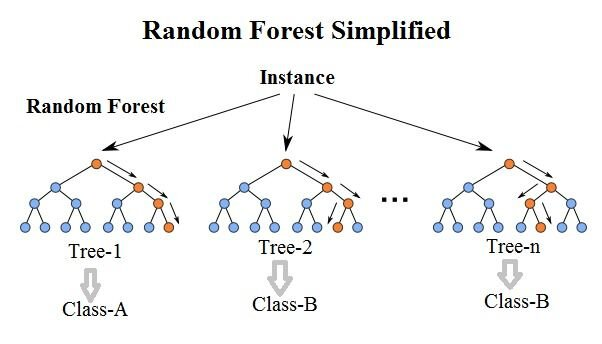

Como o nome sugere, ele é baseado em modelos de árvore de decisão. A diferença é que ele cria **muitas árvores de decisão de maneira aleatória**.

# Variáveis Mais Importantes

Outra verificação interessante que podemos fazer é em relação às features (variáveis) mais importantes para o resultado do modelo.

[interactive chart not shown]

# Conclusões - Random Forest

As variáveis mais importantes são muito valiosas, pois podem nos dar insights dos pontos mais críticos para geração de atritos, e com essa informação, podemos agir preventivamente.

Entre as principais variáveis, podemos destacar:

- Horas Extras (OverTime) - Definitivamente a mais importante das variáveis,estando bastante acima das outras.
- Salário Mensal (MonthlyIncome)
- ESOs (StockOptionLevel)
- Idade (Age)
- Anos Trabalhando (TotalWorkingYears)

Podemos identificar variáveis bastante relacionadas com a carreira, benefícios e carga horária. Altos níveis de stress? Sentimento de desvalorização? São hipóteses.